# SU-FaceMask

Sunayna Goel

March 22, 2020

# How to sew a “SU-FaceMask” with a removable filter pocket

The supply of face masks nationwide is at its critical all-time low. Many volunteers and health care professionals are at risk. This tutorial has steps and a link to the video to make an adult size face mask with a filter pocket. This mask is breathable, capable of providing good coverage, good chin and nose seal, and ability to insert any non-woven material/filter for extra protection.

I hope this effort can bring some of sewers together to make these masks for our front-line workers.

Please note this is NOT an official N95 mask.

### Material Needed

Main fabric (1 piece)- tight woven 100% cotton - 9 inches X 7.5 inches  
Liner fabric (2 pieces)- tight woven 100% cotton - 9 inches X 4.75 inches  
(same fabric can be used for the main and the liner pieces)  
¼ inch wide Ribbon (4 pieces) – 12 inches each

### Step 1:

Prewash and iron the material before cutting, it ensures that the finished mask will stay true to its size after multiple washes.

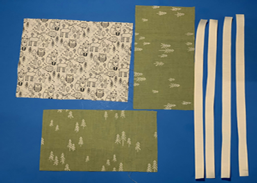

### Step 2:

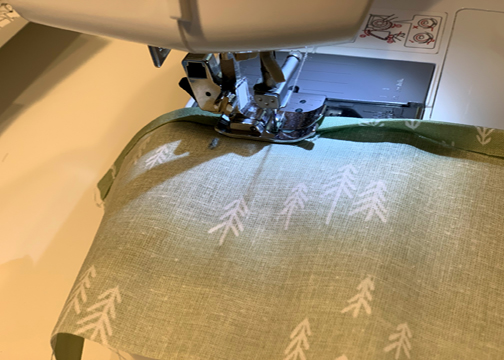

Step 2

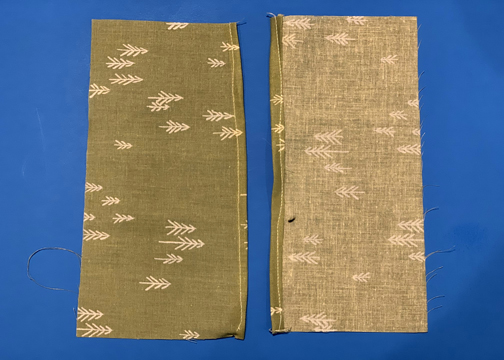

### Step 3:

Place the main fabric in front with right side facing you. Pin ribbons on the top and bottom of the short end of the main fabric.

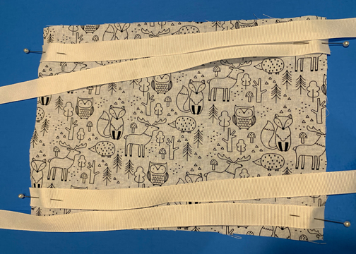

### Step 4:

Lay one of the liner fabrics on the main fabric with right side facing down, aligning it with the longer upper long end of the main fabric.

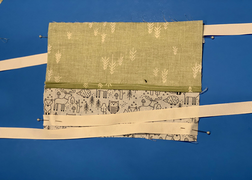

Lay the second liner fabric on the main fabric with right side facing down, aligning it with the longer lower long end of the main fabric. Pin everything together. Making sure that the ribbons stay inside, between the layers.

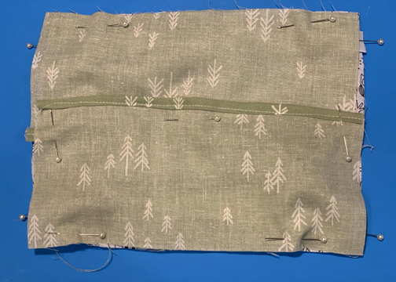

Notice that two liner fabrics will be overlapped to create the opening for the insert.

### Step 5:

Sew all the way around (all four sides), sealing all corners. Double stiches on ribbons will help to increase the durability of the mask. Don’t forget to take out the pins as you sew all the way around.

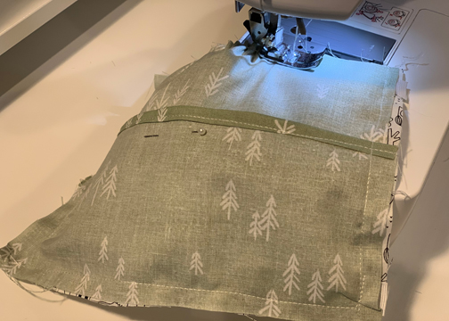

Step 5

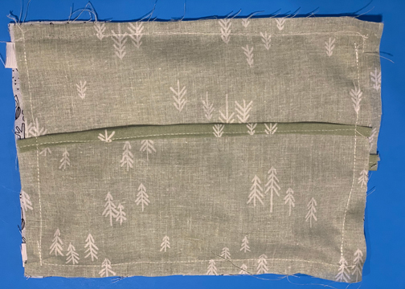

### Step 6:

Turn it inside-out (in this case outside-in) using the opening for the insert.

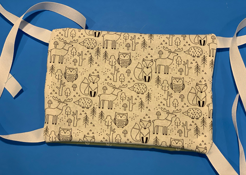

### Step 7:

Press the unfinished mask for cleaner and defined edges.

### Step 8:

Lay the mask in front with main fabric facing you. Starting from 1” from the top, iinch and tuck two sides on the short side. Pin it. Repeat it two more times creating three pin tucks.

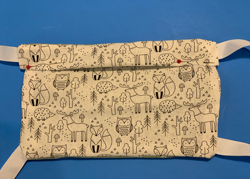

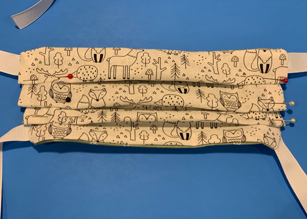

### Step 9:

Staring from one of the shorter sides, sew all around. going slow works the best for the step.

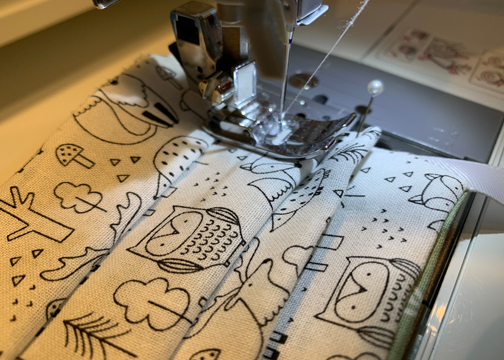

Mask is ready to use after washing. Once you take the mask off please wash it before reusing.

Extra protective disposable insert can go inside the mask from reverse side.

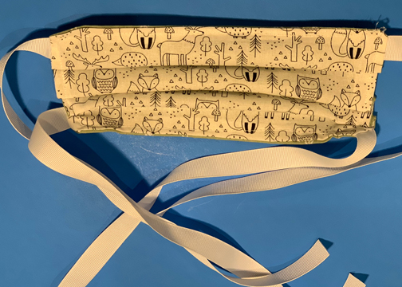

Ready Mask

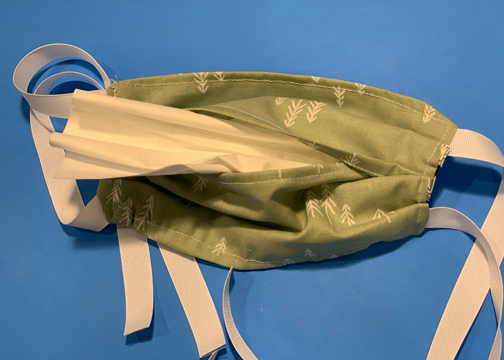

Follow the [link](https://www.youtube.com/watch?v=6UAy5wm8Efs&feature=youtu.be) for the video tutorial.

[figure not shown]

If you need any further assitance please feel free to reach out. Happy Sewing !!!

Email:sunaynaagarwal@gmail.com